# Project -5 Modelling Compressive Strength of Concrete using Regression

#### (6.6) Feature Importance.

##### Using a bunch of models to assess the importance of feature.

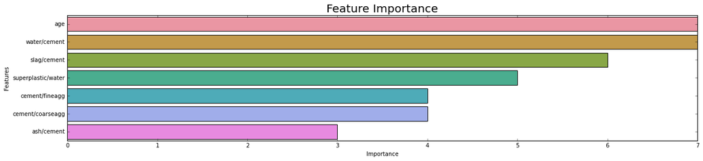

```python
model_list = {
              'LinearRegression': LinearRegression(),
              'Lasso':Lasso(),
              'Ridge':Ridge(),
              'ElasticNet':ElasticNet(),
              'RandomForestRegressor':RandomForestRegressor(),
              'DecisionTreeRegressor':DecisionTreeRegressor(),
              'CatBoostRegressor': CatBoostRegressor(verbose=False),
              'ExtraTreesRegressor':ExtraTreesRegressor()
             }
ranking_board = pd.DataFrame({'Features':df_temp.columns})

for models,model_name in zip(model_list.values(),model_list.keys()):
    rfe = RFE(estimator=models,verbose=0)
    rfe.fit(X_feat,y_feat)
    ranking_board = pd.concat([ranking_board,pd.DataFrame({model_name:rfe.ranking_ })],axis=1,join='inner')

ranking_board.set_index('Features',inplace=True)
ranking_board['Rank'] = np.ceil(np.mean(ranking_board[ranking_board.columns],axis=1))
ranking_board['Importance'] = len(ranking_board)+1 - ranking_board['Rank']
ranking_board.sort_values(by='Importance',ascending=False,inplace=True)

sns.barplot(x=ranking_board['Importance'],y=ranking_board.index,orient='h');
plt.title('Feature Importance',fontsize=20);
plt.show()
```

#### Observations:

1. As infered above`age` and `water/cement` ratio is the most important features followed by `slag/cement` ratio.
2. As infered above `ash/cement` is the least important feature in the modelling and can be dropped buring modelling.

## (7) Modeling

#### (7.1) Model Complexity - Polynomial Regression

##### Testing model fitness for polynomial degrees between 1 to 8. Expecting R2 to converge between 1 to 4.

```python
try:
    df_feat.drop('Labels',axis=1,inplace=True)
except:
    pass
```

```python
degrees = range(1,8,1)
poly_scorebord = pd.DataFrame(columns=['Degree','Validation Score','Test Score'])

X_train,X_test,y_train,y_test = train_test_split(df_feat.drop([target_var],axis=1),df_feat[target_var],test_size=0.3)
X_train_s = make_pipeline(RobustScaler(),PowerTransformer()).fit_transform(X_train)
X_test_s = make_pipeline(RobustScaler(),PowerTransformer()).fit_transform(X_test)


for i in tqdm(degrees):

    polynomial_features = PolynomialFeatures(degree=i, include_bias=False)
    linear_regression = LinearRegression()
    pipeline = Pipeline([
                         ("polynomial_features", polynomial_features),
                         ("linear_regression", linear_regression)
                       ])
    pipeline.fit(X_train_s, y_train)

    # Evaluate the models using crossvalidation
    cv_score = cross_val_score(pipeline, X_train_s, y_train,
                             scoring="r2", cv=10)
    y_pred = pipeline.predict(X_test_s)
    test_score = r2_score(y_test,y_pred)


    poly_scorebord = poly_scorebord.append({'Degree' : int(i),
                                            'Validation Score' : np.mean(abs(cv_score)),
                                            'Test Score' : abs(test_score)},ignore_index=True)
    poly_scorebord = poly_scorebord[(poly_scorebord['Test Score'] <= 1) & (poly_scorebord['Validation Score'] <= 1) ]

poly_scorebord
```

|  | Degree | Validation Score | Test Score |
| --- | --- | --- | --- |
| 0 | 1.0 | 0.799130 | 0.818490 |
| 1 | 2.0 | 0.833431 | 0.860744 |
| 2 | 3.0 | 0.856604 | 0.857494 |

```python
degree,val_score,test_score = poly_scorebord.iloc[np.argmax(poly_scorebord['Test Score'])]
score_board = score_board.append({'Test':f'Model Complexity Degree {degree}',
                                  'R2-Mean':test_score,
                                 'R2-Std':'',
                                 'Features':df_feat.drop([target_var],axis=1).columns },ignore_index=True)
score_board
```

|  | Test | R2-Mean | R2-Std | Features |
| --- | --- | --- | --- | --- |
| 0 | Baseline Score | 0.912000 | 0.0397 | Index(['cement', 'slag', 'ash', 'water', 'superplastic', 'coarseagg', 'fineagg', 'age'], dtype='object') |
| 1 | Post Feature Engineering | 0.909300 | 0.0375 | Index(['age', 'water/cement', 'ash/cement', 'slag/cement', 'cement/fineagg', 'cement/coarseagg', 'superplastic/water'], dtype='object') |
| 2 | Agglomerative Clustering Analysis | 0.905300 | 0.0386 | [age, water/cement, ash/cement, slag/cement, cement/fineagg, superplastic/water] |
| 3 | Gaussian Mixture Clustering Analysis - ash/cement | 0.908100 | 0.0343 | Index(['age', 'water/cement', 'slag/cement', 'cement/fineagg', 'cement/coarseagg', 'superplastic/water'], dtype='object') |
| 4 | Model Complexity Degree 2.0 | 0.860744 |  | Index(['age', 'water/cement', 'ash/cement', 'slag/cement', 'cement/fineagg', 'cement/coarseagg', 'superplastic/water'], dtype='object') |

#### (7.2) Model Comparisons

###### (a) Creating pipeline for scaling and normalising

```python
model_pipe = make_pipeline(RobustScaler(),PowerTransformer())
```

###### (b) Train Test and Split Origiginal and feature Engineered data frame.

```python
X_o_train,X_o_test,y_o_train,y_o_test = train_test_split(df.drop(target_var,axis=1),df[target_var],test_size=0.4,random_state=random_state)
X_o_test,X_o_val,y_o_test,y_o_val = train_test_split(X_o_test,y_o_test,test_size=0.5,random_state=random_state)
X_o_col = X_o_train.columns
X_o_col
```

```
Index(['cement', 'slag', 'ash', 'water', 'superplastic', 'coarseagg',
       'fineagg', 'age'],
      dtype='object')
```

```python
X_e_train,X_e_test,y_e_train,y_e_test = train_test_split(df_feat.drop(target_var,axis=1),df_feat[target_var],test_size=0.4,random_state=random_state)
X_e_test,X_e_val,y_e_test,y_e_val = train_test_split(X_e_test,y_e_test,test_size=0.5,random_state=random_state)
X_e_col = X_e_train.columns
X_e_col
```

```
Index(['age', 'water/cement', 'ash/cement', 'slag/cement', 'cement/fineagg',
       'cement/coarseagg', 'superplastic/water'],
      dtype='object')
```

###### (c) Pre-processing features using `PipeLine`

```python
X_o_train = model_pipe.fit_transform(X_o_train)
X_o_test = model_pipe.fit_transform(X_o_test)
X_o_val = model_pipe.fit_transform(X_o_val)
X_o_train.shape,X_o_test.shape,y_o_train.shape,y_o_test.shape,X_o_val.shape,y_o_val.shape
```

```
((618, 8), (206, 8), (618,), (206,), (206, 8), (206,))
```

```python
X_e_train = model_pipe.fit_transform(X_e_train)
X_e_test = model_pipe.fit_transform(X_e_test)
X_e_val = model_pipe.fit_transform(X_e_val)
X_e_train.shape,X_e_test.shape,y_e_train.shape,y_e_test.shape,X_e_val.shape,y_e_val.shape
```

```
((618, 7), (206, 7), (618,), (206,), (206, 7), (206,))
```

###### (d) Create data sets of `original` and `engineered` features.

```python
datasets = {'original': (X_o_train, y_o_train, X_o_val, y_o_val, X_o_test,y_o_test),
            'engineered': (X_e_train, y_e_train, X_e_val, y_e_val,X_e_test,y_e_test)
           }
```

```python
models = {'Linear' : LinearRegression(),
          'PolynomialDegree2' : make_pipeline(PolynomialFeatures(degree=2, include_bias=False),LinearRegression()),
          'PolynomialDegree3' : make_pipeline(PolynomialFeatures(degree=3, include_bias=False),LinearRegression()),
          'PolynomialDegree4' : make_pipeline(PolynomialFeatures(degree=4, include_bias=False),LinearRegression()),
          'Lasso' : Lasso(random_state = random_state),
          'Ridge' : Ridge(random_state = random_state),
          'SVR-Linear' : SVR(kernel = 'linear'),
          'SVR-RBF' : SVR(kernel = 'rbf'),
          'DecisionTreeRegressor' : DecisionTreeRegressor(random_state = random_state),
          'GradientBoostingRegressor' : GradientBoostingRegressor(random_state = random_state),
          'AdaBoostRegressor' : AdaBoostRegressor(random_state = random_state),
          'ExtraTreesRegressor' : ExtraTreesRegressor(random_state = random_state),
          'RandomForestRegressor' : RandomForestRegressor(random_state = random_state),
          'BaggingRegressor' : BaggingRegressor(DecisionTreeRegressor(random_state = random_state), random_state = random_state),
          'CatBoostRegressor' : CatBoostRegressor(random_state = random_state, silent = True),
          'LightGBMRegressor' : lgb.LGBMRegressor(random_state = random_state)
         }

model_scores = pd.DataFrame()
model_scores['Model'] = models.keys()
scoring = 'r2'

for dataset_name, (X_train, y_train, X_val, y_val, X_test, y_test) in datasets.items():
    int_score = pd.DataFrame()
    for (name, model) in models.items():
        display(int_score)
        kf = KFold(n_splits = 10, random_state = random_state)
        cv_results = cross_val_score(model, X_train, y_train, cv = kf, scoring = scoring)
        mfit = model.fit(X_train, y_train)
        y_pred = mfit.predict(X_test)
        test_score = r2_score(y_test,y_pred)
        score_dict = {'Model' : name,
                      dataset_name : [cv_results.mean().round(4), cv_results.std().round(4), test_score.round(4)]
                     }
        int_score = int_score.append(score_dict,ignore_index = True)
        clear_output( wait=True)
    model_scores = pd.merge(model_scores,int_score,on='Model')
model_scores.set_index("Model",inplace=True)
model_scores = model_scores.rename(columns={x:x+' [R2.Train,R2.StdDev,R2.Test]'  for x in model_scores.columns})
display(model_scores)
```

| Model | original [R2.Train,R2.StdDev,R2.Test] | engineered [R2.Train,R2.StdDev,R2.Test] |
| --- | --- | --- |
| Linear | [0.8093, 0.0322, 0.7799] | [0.8044, 0.0348, 0.7786] |
| PolynomialDegree2 | [0.8558, 0.0262, 0.8093] | [0.8498, 0.0342, 0.7983] |
| PolynomialDegree3 | [0.8479, 0.0541, 0.5402] | [0.8367, 0.061, 0.8273] |
| PolynomialDegree4 | [-2.5322375098042302e+19, 3.873814993033945e+19, -3.455670630703313e+18] | [-18.0851, 36.0476, -76.6091] |
| Lasso | [0.782, 0.0425, 0.7357] | [0.7805, 0.0422, 0.7387] |
| Ridge | [0.8094, 0.0322, 0.7794] | [0.8044, 0.0347, 0.778] |
| SVR-Linear | [0.8071, 0.0332, 0.7671] | [0.7996, 0.0375, 0.7615] |
| SVR-RBF | [0.7411, 0.0416, 0.7203] | [0.7565, 0.0478, 0.756] |
| DecisionTreeRegressor | [0.7504, 0.0957, 0.7494] | [0.7975, 0.0593, 0.7985] |
| GradientBoostingRegressor | [0.8833, 0.041, 0.8447] | [0.877, 0.0435, 0.8467] |
| AdaBoostRegressor | [0.7676, 0.034, 0.7999] | [0.7764, 0.032, 0.7832] |
| ExtraTreesRegressor | [0.8977, 0.0472, 0.885] | [0.8929, 0.0439, 0.8733] |
| RandomForestRegressor | [0.884, 0.0513, 0.8654] | [0.8844, 0.043, 0.8524] |
| BaggingRegressor | [0.8615, 0.0673, 0.8617] | [0.8648, 0.0464, 0.8271] |
| CatBoostRegressor | [0.9188, 0.0277, 0.8859] | [0.9092, 0.0329, 0.8728] |
| LightGBMRegressor | [0.8983, 0.0425, 0.8886] | [0.8961, 0.0386, 0.8354] |

#### Observations:

###### (e) Hyperparameter Tuning of CatBoostRegressor

###### Create a score board for different types of hyperparameter tuning.

```python
hyper_score = pd.DataFrame(columns = ['Dataset','Train_Score','Train_StdDev','Test_Score', 'Best_Params', 'Tune_Params', 'Comments'])
```

###### Create a function to generate train,validation or test sets

```python
def get_train_val_test(X,y,random_state):

    X_train,X_test,y_train,y_test = train_test_split(X,y,test_size=0.4,random_state=random_state)
    X_test,X_val,y_test,y_val = train_test_split(X_test,y_test,test_size=0.5,random_state=random_state)
    model_pipe = make_pipeline(RobustScaler(),PowerTransformer())
    X_train = model_pipe.fit_transform(X_train)
    X_test = model_pipe.fit_transform(X_test)
    X_val = model_pipe.fit_transform(X_val)
    return (X_train,y_train,X_val,y_val,X_test,y_test)
```

##### Create the tuning grid.

```python
# tune_grid = {
#             "depth": list(range(1, 12)),
#             "n_estimators": np.arange(100, 1000, 100),
#             "random_strength": np.arange(0, 0.9, 0.1),
#             "l2_leaf_reg": [1, 2, 3, 4, 5, 6, 7, 8, 9, 10, 20, 30, 50, 100, 200],
#             "learning_rate": np.arange(0.01, 0.31, 0.05),
#             "min_data_in_leaf": np.arange(1,10,1),
#         }

tune_grid = {'learning_rate': np.arange(0.01, 0.31, 0.05),
             'depth': [3, 4, 5, 6, 7, 8, 9, 10],
             'l2_leaf_reg': np.arange(2, 10, 1)}



datasets = {
#             'original': get_train_val_test(df.drop(target_var,axis=1),df[target_var],random_state=random_state),
            'engineered': get_train_val_test(df_feat.drop([target_var],axis=1),df_feat[target_var],random_state=random_state)
           }
```

```python
for search_type in ['random','grid']:
    display(f"{search_type} in Progress")
    for dataset_name, (X_train, y_train, X_val, y_val, X_test, y_test) in datasets.items():
        display(hyper_score)
        cat_reg = CatBoostRegressor(iterations = None,
                                    random_state = random_state,
                                    od_type = 'Iter',
                                    od_wait = 5,
                                    eval_metric='R2',
                                    silent=True)

        if search_type == 'random':
            rf_random = RandomizedSearchCV(cat_reg,
                                           param_distributions=tune_grid,
                                           n_iter = 100,
                                           cv = 5,
                                           verbose=False,
                                           random_state=random_state,
                                           n_jobs=-3,
                                           scoring='r2')

        else :
            rf_random = GridSearchCV(cat_reg,
                                     tune_grid,
                                     cv = 5,
                                     verbose=False,
                                     n_jobs=-3,
                                     scoring='r2')

        rf_random.fit(X_train, y_train)

        reg_model = CatBoostRegressor(silent = True,
                                      random_state = random_state,
                                      od_type = 'Iter',
                                      od_wait = 5,
                                      eval_metric='R2',
                                      **rf_random.best_params_)

        reg_model.fit(X = X_train, y = y_train)

        y_reg_predict = reg_model.predict(X_val)

        test_score = r2_score(y_val,y_reg_predict)

        best_train_score = rf_random.cv_results_['mean_test_score'].max()
        best_train_std = rf_random.cv_results_['std_test_score'][np.argwhere(rf_random.cv_results_['mean_test_score'] == best_train_score)]

        comments = f"{search_type} search for dataset {dataset_name} with all engineered features "

        hyper_score = hyper_score.append({'Dataset' : dataset_name,
                                          'Train_Score' : np.round(best_train_score,6) ,
                                          'Train_StdDev' :np.round(best_train_std,6),
                                          'Test_Score' : test_score,
                                          'Best_Params' : rf_random.best_params_,
                                          'Tune_Params' :tune_grid,
                                          'Comments' : comments,
                                         },ignore_index=True)
        clear_output( wait=True)

    display(hyper_score)
```

|  | Dataset | Train_Score | Train_StdDev | Test_Score | Best_Params | Tune_Params | Comments |
| --- | --- | --- | --- | --- | --- | --- | --- |
| 0 | engineered | 0.908196 | [[0.009168]] | 0.851599 | {'learning_rate': 0.11, 'l2_leaf_reg': 4, 'depth': 5} | {'learning_rate': [0.01, 0.060000000000000005, 0.11, 0.16000000000000003, 0.21000000000000002, 0.26], 'depth': [3, 4, 5, 6, 7, 8, 9, 10], 'l2_leaf_reg': [2, 3, 4, 5, 6, 7, 8, 9]} | random search for dataset engineered with ash/cement removed |
| 1 | engineered | 0.908657 | [[0.009638]] | 0.842494 | {'depth': 5, 'l2_leaf_reg': 5, 'learning_rate': 0.16000000000000003} | {'learning_rate': [0.01, 0.060000000000000005, 0.11, 0.16000000000000003, 0.21000000000000002, 0.26], 'depth': [3, 4, 5, 6, 7, 8, 9, 10], 'l2_leaf_reg': [2, 3, 4, 5, 6, 7, 8, 9]} | grid search for dataset engineered with ash/cement removed |
| 2 | original | 0.921698 | [[0.012985]] | 0.844703 | {'learning_rate': 0.21000000000000002, 'l2_leaf_reg': 3, 'depth': 4} | {'learning_rate': [0.01, 0.060000000000000005, 0.11, 0.16000000000000003, 0.21000000000000002, 0.26], 'depth': [3, 4, 5, 6, 7, 8, 9, 10], 'l2_leaf_reg': [2, 3, 4, 5, 6, 7, 8, 9]} | random search for dataset original |
| 3 | engineered | 0.912533 | [[0.012638]] | 0.877923 | {'learning_rate': 0.16000000000000003, 'l2_leaf_reg': 2, 'depth': 6} | {'learning_rate': [0.01, 0.060000000000000005, 0.11, 0.16000000000000003, 0.21000000000000002, 0.26], 'depth': [3, 4, 5, 6, 7, 8, 9, 10], 'l2_leaf_reg': [2, 3, 4, 5, 6, 7, 8, 9]} | random search for dataset engineered with all engineered features |
| 4 | engineered | 0.912912 | [[0.009055]] | 0.845836 | {'depth': 6, 'l2_leaf_reg': 9, 'learning_rate': 0.21000000000000002} | {'learning_rate': [0.01, 0.060000000000000005, 0.11, 0.16000000000000003, 0.21000000000000002, 0.26], 'depth': [3, 4, 5, 6, 7, 8, 9, 10], 'l2_leaf_reg': [2, 3, 4, 5, 6, 7, 8, 9]} | grid search for dataset engineered with all engineered features |

```python
display(hyper_score)
```

|  | Dataset | Train_Score | Train_StdDev | Test_Score | Best_Params | Tune_Params | Comments |
| --- | --- | --- | --- | --- | --- | --- | --- |
| 0 | engineered | 0.908196 | [[0.009168]] | 0.851599 | {'learning_rate': 0.11, 'l2_leaf_reg': 4, 'depth': 5} | {'learning_rate': [0.01, 0.060000000000000005, 0.11, 0.16000000000000003, 0.21000000000000002, 0.26], 'depth': [3, 4, 5, 6, 7, 8, 9, 10], 'l2_leaf_reg': [2, 3, 4, 5, 6, 7, 8, 9]} | random search for dataset engineered with ash/cement removed |
| 1 | engineered | 0.908657 | [[0.009638]] | 0.842494 | {'depth': 5, 'l2_leaf_reg': 5, 'learning_rate': 0.16000000000000003} | {'learning_rate': [0.01, 0.060000000000000005, 0.11, 0.16000000000000003, 0.21000000000000002, 0.26], 'depth': [3, 4, 5, 6, 7, 8, 9, 10], 'l2_leaf_reg': [2, 3, 4, 5, 6, 7, 8, 9]} | grid search for dataset engineered with ash/cement removed |
| 2 | original | 0.921698 | [[0.012985]] | 0.844703 | {'learning_rate': 0.21000000000000002, 'l2_leaf_reg': 3, 'depth': 4} | {'learning_rate': [0.01, 0.060000000000000005, 0.11, 0.16000000000000003, 0.21000000000000002, 0.26], 'depth': [3, 4, 5, 6, 7, 8, 9, 10], 'l2_leaf_reg': [2, 3, 4, 5, 6, 7, 8, 9]} | random search for dataset original |
| 3 | engineered | 0.912533 | [[0.012638]] | 0.877923 | {'learning_rate': 0.16000000000000003, 'l2_leaf_reg': 2, 'depth': 6} | {'learning_rate': [0.01, 0.060000000000000005, 0.11, 0.16000000000000003, 0.21000000000000002, 0.26], 'depth': [3, 4, 5, 6, 7, 8, 9, 10], 'l2_leaf_reg': [2, 3, 4, 5, 6, 7, 8, 9]} | random search for dataset engineered with all engineered features |
| 4 | engineered | 0.912912 | [[0.009055]] | 0.845836 | {'depth': 6, 'l2_leaf_reg': 9, 'learning_rate': 0.21000000000000002} | {'learning_rate': [0.01, 0.060000000000000005, 0.11, 0.16000000000000003, 0.21000000000000002, 0.26], 'depth': [3, 4, 5, 6, 7, 8, 9, 10], 'l2_leaf_reg': [2, 3, 4, 5, 6, 7, 8, 9]} | grid search for dataset engineered with all engineered features |

#### Observations:

```python
best_cbt_params = hyper_score.iloc[3]['Best_Params']
best_cbt_params
```

```
{'learning_rate': 0.16000000000000003, 'l2_leaf_reg': 2, 'depth': 6}
```

```python
model_pipe = make_pipeline(RobustScaler(),PowerTransformer())
x_vals = model_pipe.fit_transform(df_feat.drop([target_var],axis=1))
values = np.append(x_vals,df_feat[['strength']].values,axis=1)

n_iterations = 300 # Number of bootstrap samples to create
n_size = int(len(values) * 1) # size of a bootstrap sample

# run bootstrap
r2_stats = [] # empty list that will hold the scores for each bootstrap iteration
for i in tqdm(range(n_iterations)):
    train = resample(values, n_samples = n_size) # Sampling with replacement
    test = np.array([x for x in values if x.tolist() not in train.tolist()]) # picking rest of the data not considered in sample

  # fit model
    gb_reg_grid = CatBoostRegressor(silent = True,
                                      random_state = random_state,
                                      od_type = 'Iter',
                                      od_wait = 5,
                                      eval_metric='R2',
                                      **best_cbt_params)


    gb_reg_grid.fit(train[:, :-1], train[:, -1]) # fit against independent variables and corresponding target values

  # evaluate model
    predictions = gb_reg_grid.predict(test[:, :-1]) # predict based on independent variables in the test data
    score = r2_score(test[:, -1], predictions)
    r2_stats.append(score)
display(r2_stats)
```

[output not shown]

[output cut: 245 more lines]

[output not shown]

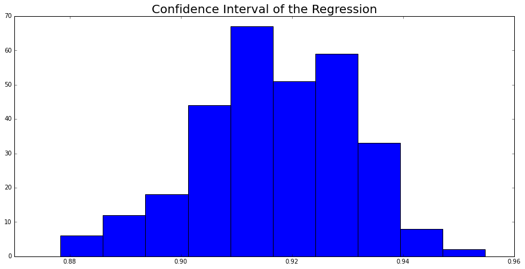

95.0% confidence interval 0.89 and 0.94

```python
plt.figure(figsize = (15, 7.2))
plt.hist(r2_stats)

# confidence intervals
alpha = 0.95 # for 95% confidence
p = ((1.0 - alpha) / 2.0) * 100 # tail regions on right and left .25 on each side indicated by P value (border)
lower = max(0.0, np.percentile(r2_stats, p))

p = (alpha + ((1.0 - alpha) / 2.0)) * 100
upper = min(1.0, np.percentile(r2_stats, p))
plt.title("Confidence Interval of the Regression",fontsize=20)
plt.show()
display(Markdown(f"### {alpha*100}% confidence interval {lower:.2f} and {upper:.2f}"))
```

### Conclusion:

1. The EDA showed that there is a significant correlation among dependent variables and also between the dependent and target variable.
2. Features were reingineered by taking ratios of individual features such that it aligns and appeals to the domain expert such as `water/cement` ratio etc.
3. Gaussian Mixtures in the data set were analysed and about 19 clusters were drawn from the dataset using `AIC` and `BIC`.
4. The difference between `high strength` and `low strength` conceretes were analysed and it was found that `ash/cement` contributed the least to the overall model performance.
5. Feature importances were drawn from mix of linear,polynomial,tree and ensemble based regressors.
6. `Model Complexity` was analysed and it was found that `Polynomial Regression of Degree 2` performs best when compared to higher or lower degreees.
7. Outliers were analysed, the dataset seem to have more `Leverage` points when compared to `Outliers` and hence they were retained as it is.
8. A bunch of regression models were compared against a train and validation data set and found that `CatBoostRegressor` performs better than the rest in the mix.
9. Hyperparameter were tuned based on `Randomized` and `Grid` searches and found that `Randomized` search was faster and better than the `Grid` search tuning.
10. Given the dataset, there is a `95% likelihood` that the R2 is in the range `0.89 to 0.94`.